# ACT REPORT

## Insights

In the first observation/ Insight, I obtained the descriptive parameters of the different numeric data and attained the conclusions below.

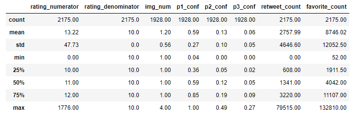

##### Key observations.

> p1_conf,p2_conf,p3_conf are confidence intervals are all ranging between 0 and 1.

> For the retweet_count and favorite_count columns, basing on the mean, the mean shows that more tweets are "favorited" that retweeted.

> img_num shows that atleast every tweet has an image and 4 is the highest number of images on a tweet.

In insight four, a review was performed to attained the most common rating numerator (rating) that is awarded to majority of the dogs.  
It was then observed that a rating of 12 is the most common awarded rating having been awarded to over 500 dogs followed by a rating of 10.  
It was futher noticed that majority of th edog attained a rating between 8 and 14 thus producing a mean rating of 13.22 as observed from the data description table in insight one. The visualisation below is for the rating count.

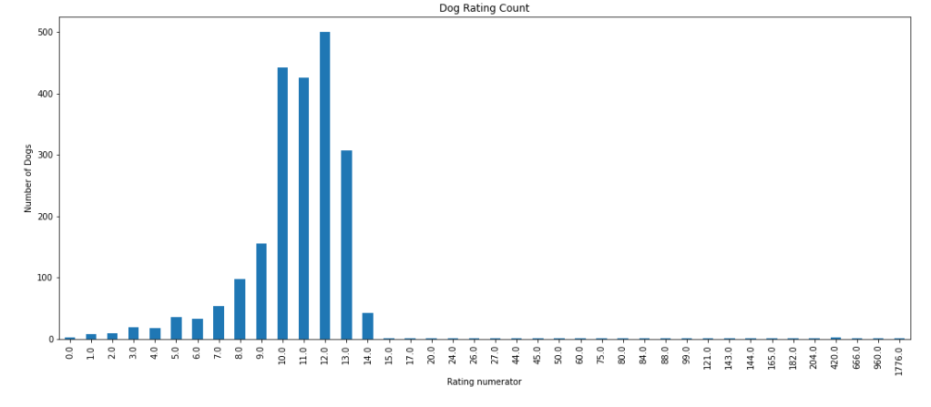

In insight five, an analysis was established to attain the most common dog names and the visualisation below was produced.

##### Key observation.

Lucy and Charlie are the most common dog names with 11 dogs having those names.  
Oliver and Cooper are the third and forth most common dog names with 10 dogs being named so.

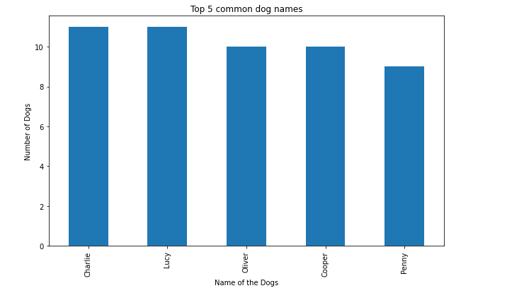

In insight six, a review was made on the source of the different tweets to establish an understanding of which sources are mostly used to make the tweets.  
It was the observed that Twitter for iphone was the common source of the tweets as seen from the visualisation below.

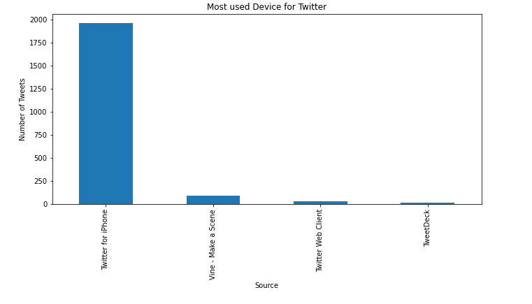

## Visualisations

In visualiation 1, this is intended to produce a relationship between retweet count and favorite count of each tweet and attain a correlation between the two variables.

It was therefore noticed that there is a positive correlation between the two variables implying that as a tweet attains more retweets, it attains the favorite selection and if a tweet attains less retweets, it attains low favorite selection as well.

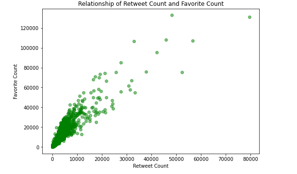

In visualition 2, a broad study and analysis is made on the different numeric variables and a seaborn pairplot is made to attain a relationship study and pattern discovery in the numeric data.

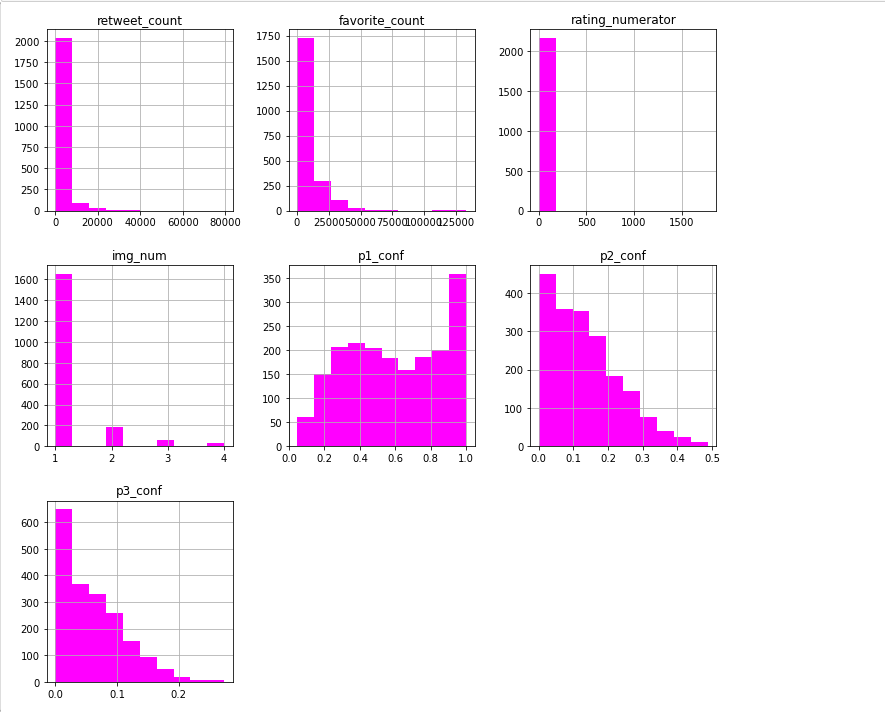

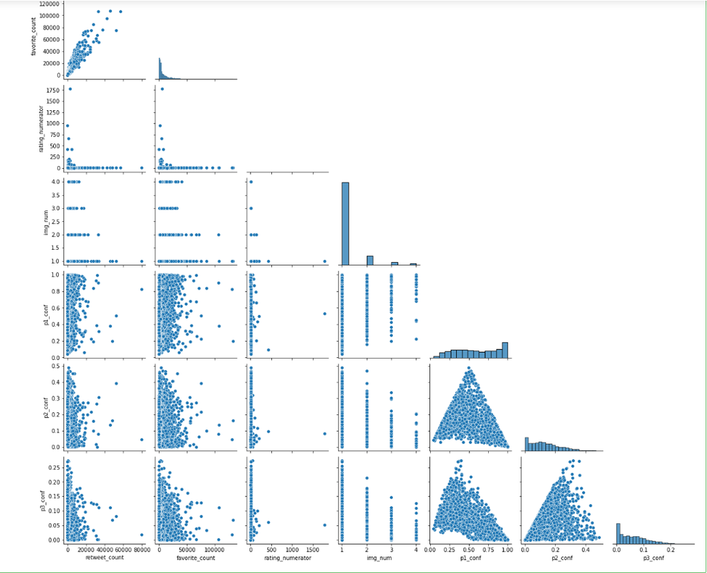